# Lab 9: Fitting Models to Data

Statistical Computing, 36-350

Week of Tuesday July 24, 2018

Name: Gabriel Krotkov Andrew ID: gkrotkov Collaborated with:

This lab is to be done in class (completed outside of class if need be). You can collaborate with your classmates, but you must identify their names above, and you must submit **your own** lab as an knitted HTML file on Canvas, by Tuesday 10pm, this week.

**This week’s agenda**: exploratory data analysis, cleaning data, fitting linear models, and using associated utility functions.

# Prostate cancer data

Recall the data set on 97 men who have prostate cancer (from the book [The Elements of Statistical Learning](http://statweb.stanford.edu/~tibs/ElemStatLearn/)). Reading it into our R session:

```r
pros.df =
  read.table("http://www.stat.cmu.edu/~ryantibs/statcomp/data/pros.dat")
dim(pros.df)
```

```
## [1] 97  9
```

```r
head(pros.df, 3)
```

```
##       lcavol  lweight age      lbph svi       lcp gleason pgg45       lpsa
## 1 -0.5798185 2.769459  50 -1.386294   0 -1.386294       6     0 -0.4307829
## 2 -0.9942523 3.319626  58 -1.386294   0 -1.386294       6     0 -0.1625189
## 3 -0.5108256 2.691243  74 -1.386294   0 -1.386294       7    20 -0.1625189
```

# Simple exploration and linear modeling

- **1a.** Define `pros.df.subset` to be the subset of observations (rows) of the prostate data set such the `lcp` measurement is greater than the minimum value (the minimum value happens to be `log(0.25)`, but you should not hardcode this value and should work it out from the data). As in lecture, plot histograms of all of the variables in `pros.df.subset`. Comment on any differences you see between these distributions and the ones in lecture.

```r
pros.df.subset <- subset(pros.df, subset = pros.df$lcp > min(pros.df$lcp))
```

- **1b.** Also as in lecture, compute and display correlations between all pairs of variables in `pros.df.subset`. Report the two highest correlations between pairs of (distinct) variables, and also report the names of the associated variables. Are these different from answers that were computed on the full data set?

```r
pros.cor <- cor(pros.df.subset)
pros.cor[lower.tri(pros.cor,diag=TRUE)] = 0 # Why only upper tri part?
pros.cor.sorted = sort(abs(pros.cor),decreasing=T)

high_cor_ind = arrayInd(which(abs(pros.cor)==pros.cor.sorted[1]),
                       dim(pros.cor))
pair <- colnames(pros.df)[high_cor_ind]

cat("The highest correlation is:", pros.cor.sorted[1], "between:", pair, "\n")
```

```
## The highest correlation is: 0.8049728 between: lcavol lcp
```

```r
high_cor_ind = arrayInd(which(abs(pros.cor)==pros.cor.sorted[2]),
                       dim(pros.cor))
pair <- colnames(pros.df)[high_cor_ind]

cat("The second highest correlation is:", pros.cor.sorted[2], "between:", pair, "\n")
```

```
## The second highest correlation is: 0.6246382 between: svi lcp
```

- **1c.** Compute, using `lm()`, a linear regression model of `lpsa` (log PSA score) on `lcavol` (log cancer volume). Do this twice: once with the full data set, `pros.df`, and once with the subsetted data, `pros.df.subset`. Save the results as `pros.lm.` and `pros.subset.lm`, respectively. Using `coef()`, display the coefficients (intercept and slope) from each linear regression. Are they different?

```r
pros.lm <- lm(lpsa ~ lcavol, data = pros.df)
pros.subset.lm <- lm(lpsa ~ lcavol, data = pros.df.subset)

coef(pros.lm)
```

```
## (Intercept)      lcavol
##   1.5072975   0.7193204
```

```r
coef(pros.subset.lm)
```

```
## (Intercept)      lcavol
##   1.6695707   0.6725807
```

Answer: The results are different, but we’d have to examine the standard errors to see by how much we should really consider this difference.

- **1d.** Let’s produce a visualization to help us figure out how different these regression lines really are. Plot `lpsa` versus `lcavol`, using the full set of observations, in `pros.df`. Label the axes appropriately. Then, mark the observations in `pros.df.subset` by small filled red circles. Add a thick black line to your plot, displaying the fitted regression line from `pros.lm`. Add a thick red line, displaying the fitted regression line from `pros.subset.lm`. Add a legend that explains the color coding.

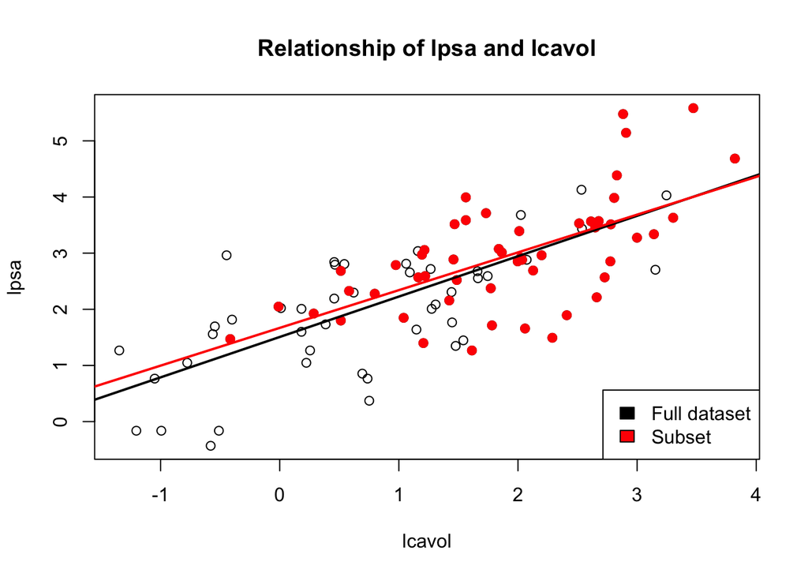

```r
plot(pros.df$lcavol, pros.df$lpsa,
     xlab = "lcavol", ylab = "lpsa", main = "Relationship of lpsa and lcavol")
points(pros.df.subset$lcavol, pros.df.subset$lpsa,
       col = "red", pch = 19)
abline(pros.lm, col = "black", lwd = 2)
abline(pros.subset.lm, col = "red", lwd = 2)
legend("bottomright",
       legend = c("Full dataset", "Subset"),
       fill = c("Black", "Red"))
```

# Exoplanets data set

There are now over 1,000 confirmed planets outside of our solar system. They have been discovered through a variety of methods, with each method providing access to different information about the planet. Many were discovered by NASA’s Kepler space telescope, which observes the “transit” of a planet in front of its host star. In these problems you will use data from the [NASA Exoplanet Archive](http://exoplanetarchive.ipac.caltech.edu) to investigate some of the properties of these exoplanets. (You don’t have to do anything yet, this was just by way of background.)

# Reading in, cleaning data

- **2a.** A data table of dimension 1892 x 10 on exoplanets (planets outside of our solar system, i.e., which orbit anothet star, other than our sun) is up at http://www.stat.cmu.edu/~ryantibs/statcomp/data/exoplanets.csv. Load this data table into your R session with `read.csv()` and save the resulting data frame as `exo.df`. (Hint: the first 13 lines of the linked filed just explain the nature of the data, so you can use an appropriate setting for the `skip` argument in `read.csv()`.) Check that `exo.df` has the right dimensions, and display its first 3 rows.

```r
url <- "http://www.stat.cmu.edu/~ryantibs/statcomp/data/exoplanets.csv"
exo.df <- read.csv(url, skip = 13)

head(exo.df, 3)
```

```
##   rowid pl_hostname pl_letter   pl_discmethod pl_pnum pl_orbper pl_orbsmax
## 1     1      11 Com         b Radial Velocity       1    326.03       1.29
## 2     2      11 UMi         b Radial Velocity       1    516.22       1.54
## 3     3      14 And         b Radial Velocity       1    185.84       0.83
##   pl_massj pl_msinij st_mass
## 1       NA      19.4     2.7
## 2       NA      10.5     1.8
## 3       NA       4.8     2.2
```

- **2b.** The last 6 columns of the `exo.df` data frame, `pl_pnum`,`pl_orbper`, `pl_orbsmax`, `pl_massj`, `pl_msinij`, and `st_mass`, are all numeric variables. Define a matrix `exo.mat` that contains these variables as columns. Display the first 3 rows of `exo.mat`.

```r
exo.mat <- as.matrix(exo.df[,5:10])

head(exo.mat, 3)
```

```
##      pl_pnum pl_orbper pl_orbsmax pl_massj pl_msinij st_mass
## [1,]       1    326.03       1.29       NA      19.4     2.7
## [2,]       1    516.22       1.54       NA      10.5     1.8
## [3,]       1    185.84       0.83       NA       4.8     2.2
```

- **2c.** As we can see, at least one of the columns, `pl_massj`, has many NA values in it. How many missing values are present in each of the 6 columns of `exo.mat`? (Hint: you can do this easily with vectorization, you shouldn’t use any loops.)

```r
colSums(is.na(exo.mat))
```

```
##    pl_pnum  pl_orbper pl_orbsmax   pl_massj  pl_msinij    st_mass
##          0         59        167       1350       1363        413
```

- **2d.** Define `ind.clean` to be the vector of row indices corresponding to the “clean” rows in `exo.mat`, i.e., rows for which there are no NAs among the 6 variables. (Hint: again, you can do this easily with vectorization, you shouldn’t use any loops.) Use `ind.clean` to define `exo.mat.clean`, a new matrix containing the corresponding clean rows of `exo.mat`. How many rows are left in `exo.mat.clean`?

```r
ind.clean <- (rowSums(is.na(exo.mat)) == 0)
exo.mat.clean <- exo.mat[ind.clean,]
cat("The number of clean rows in exo.mat is:", nrow(exo.mat.clean))
```

```
## The number of clean rows in exo.mat is: 7
```

- **2e.** Yikes! You should have seen that, because there are so many missing values (NA values) in `exo.mat`, we only have 7 rows with complete observations! This is far too little data. Because of this, we’re going to restrict our attention to the variables `pl_orbper`, `st_mass`, and `pl_orbsmax`. Redefine `exo.mat` to contain just these 3 variables as columns. Then repeat the previous part, i.e., define `ind.clean` to be the vector of row indices corresponding to the “clean” rows in `exo.mat`, and define `exo.mat.clean` accordingly. Now, how many rows are left in `exo.mat.clean`? Finally, check that `exo.mat.clean` is the same as the result of calling `na.omit()` (a handy built-in R function) on `exo.mat`. You can check for equality using `all.equal()` with the argument `check.attributes=FALSE`.

```r
exo.mat <- exo.mat[,c(2, 3, 6)]

ind.clean <- (rowSums(is.na(exo.mat)) == 0)
exo.mat.clean <- exo.mat[ind.clean,]
cat("The number of clean rows in exo.mat is now:", nrow(exo.mat.clean))
```

```
## The number of clean rows in exo.mat is now: 1269
```

# Exploring the exoplanets

- **3a.** Compute histograms of each of the variables in `exo.mat.clean`. Set the titles and label the x-axes appropriately (indicating the variable being considered). What do you notice about these distributions?

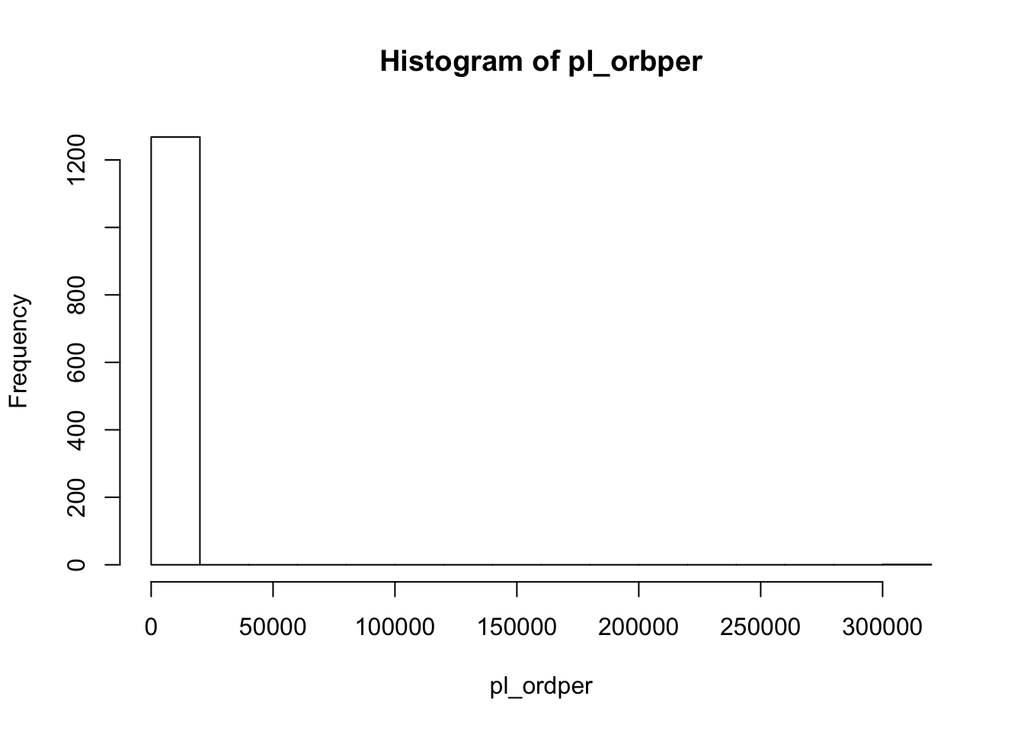

```r
hist(exo.mat.clean[,1], main = "Histogram of pl_orbper", xlab = "pl_ordper")
```

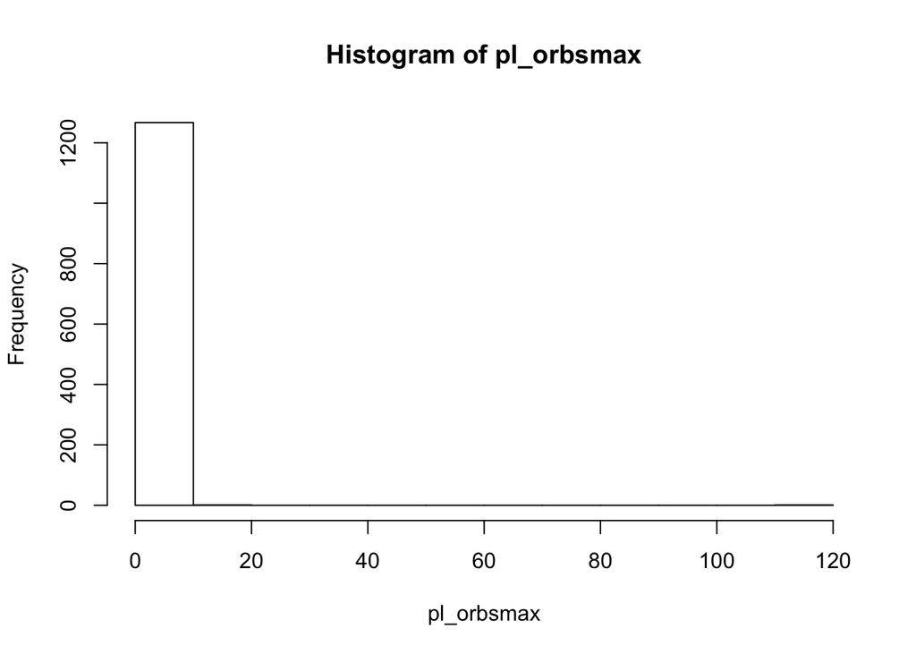

```r
hist(exo.mat.clean[,2], main = "Histogram of pl_orbsmax", xlab = "pl_orbsmax")
```

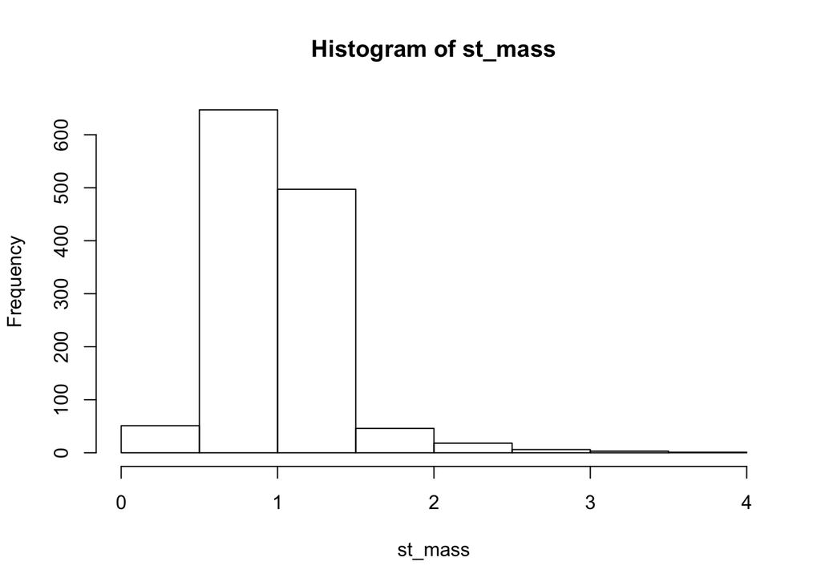

```r
hist(exo.mat.clean[,3], main = "Histogram of st_mass", xlab = "st_mass")
```

Answer: The default breaks for `pl_orbper` and `pl_orbsmax` concentrate in a single bar, indicating that there is a wide rage but relatively few values in higher segments of the graph.

- **3b.** Apply a log transformation to the variables in `exo.mat.clean`, saving the resulting matrix as `exo.mat.clean.log`. Name the columns of `exo.mat.clean.log` to be “pl_orbper_log”, “st_mass_log”, and “pl_orbsmax_log”, respectively, to remind yourself that these variables are log transformed. Recompute histograms as in the last question. Now what do you notice about these distributions?

```r
# Note - this log transform introduces NA values!
exo.mat.clean.log <- log(exo.mat)
colnames(exo.mat.clean.log) <- paste("log", colnames(exo.mat.clean.log),
                                     sep = "")
```

- **3c.** Plot the relationships between pairs of variables in `exo.mat.clean.log` with `pairs()`. What do you notice?

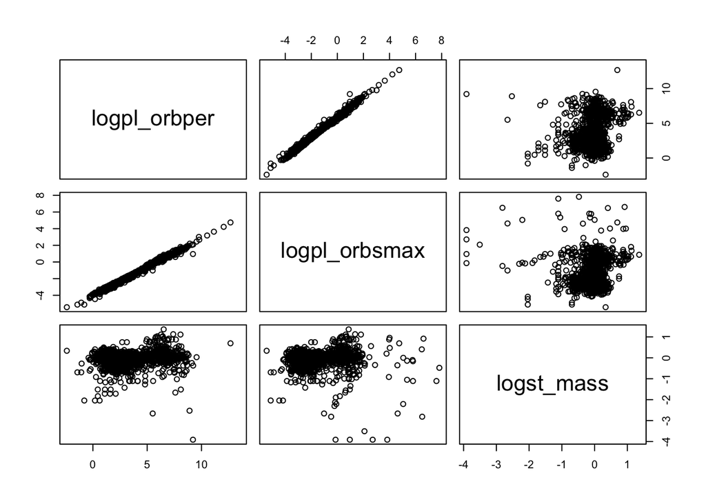

```r
pairs(~ logpl_orbper + logpl_orbsmax + logst_mass,
      data = exo.mat.clean.log)
```

Answer: `logpl_orbsmax` and `logpl_orbper` are *extremely* closely related, while the other correlations appear fairly weak.